# Stats 531 Final project: POMP modeling to investigate Foreign Currency Exchange Rate volatility

4/24/2020

# Outline

- 1 Summary
- 2 Indroduction
- 3 Dataset
- 4 Mathematical Model
  - 4.1 Geometric Brownian Motion(GBM) Model
  - 4.2 Parameter Description
- 5 POMP Model
  - 5.1 Building POMP Model
  - 5.2 Set Run levels
- 6 Likelihood Slice
- 7 Partical Filter
- 8 Iterated Filetering on Data
  - 8.1 Maximization and Likelihood Evaluation
  - 8.2 Likelihood Surface Evaluation
- 9 Global Search with Randomized Starting Values
  - 9.1 Iterated Filetering with randomized starting values
  - 9.2 Global Geometry of the likelihood surface
- 10 GARCH Model
  - 10.1 Model Description
  - 10.2 Log Likelihood
  - 10.3 Diagnose Plot
- 11 Conclusion
- 12 Limitation and Future Work
- 13 Acknowledgement
- 14 References

# 1 Summary

There has been major impact on global economy with the COVID-19 pandemic. To understand how financial volatity can be studied through foreign exchange rate data, this final project performs time series analysis to implement POMP and GARCH. UK pound or GBP/USD is taken for the purpose of study. Goal of this project are as follows:

- To experiment with Partially Observed Markov Process (POMP) and investgate how it can be used to understand the volatility of financial markets or foreign exchange rates.
- The models we develop do not quite have the standard POMP structure, since the observed variable (Exchange Rate ) has some effect on the dynamics of the latent variable (volatility). Therefore I aim to learn how to adapt standard POMP methods for this situation.
- To understand and compare POMP and GARCH model.

# 2 Introduction

Exchange rate in the COVID-19 pandemic, are important signal to global policymaker of underlying health of economy. Economists have been trying to study the foreign exchange rate for years. From some research paper, Geometric Brownian Motion (GBM) has been proved useful in simulating financial data (Brewer, K., Feng, Y., & Kwan, C, 2012). Gerber, for example, points out in the paper that GBM could be used to model assets and liability (Gerber, H., & Shiu, E., 2003). Motivated by those research papaers, I want to experiment with time series models and technique on the of foreign exchange rate.

I want to address the question whether GBM POMP is suitable for fitting the UK pound GBM/USD exchange rate. I have used POMP model and Particle filter approach to get unbiased Monte Carlo estimate of log likelihood. I further evaluated my selection of model with the help methods like Likelihood surface evaluation and global search evaluuation. Also, I build the GARCH model and calculate its log likelihood and perform diagnostics like QQ plot and ACF plot to see the validity of model’s assumption.

# 3 Dataset

Dataset used in the project is from the website of Federal Reserve System:- (https://www.federalreserve.gov/releases/h10/Hist/dat00_uk.htm).The dataset has two variables Date and Rate (GBP/USD exchange rate). It is a daily data recording GBP/USD exchange rate from the year 2000 to April 15 2020. It has 5092 observations after removing the missing values. The missing data represents that the market is closed for that day. There are around 252 data points for each year.For computational purpose, I have selected only 300 subset of the dataset i.e. foreign exchange rate around the year 2010 and 2011. The economic market was quite stable at that time.

- We write ${N_t,t=1,\dots,T}$ for the data.

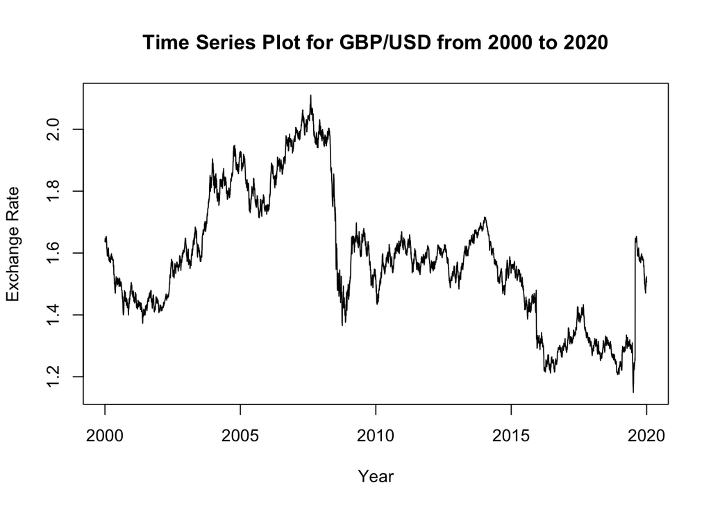

Figure 1. Time Series of Original Data

- Figure 1 (above) shows the times series plot of the whole data set. There is a sharp decrease in the year 2008, which was caused by the Financial Crisis.

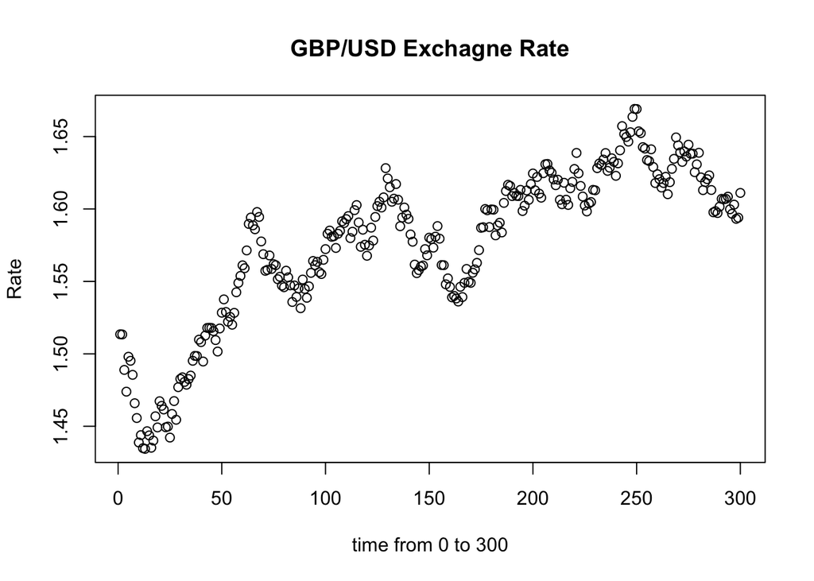

Figure 2. Time Series of Used Data

- Figure 2 shows a subset of 300 data points, it covers the year from 2010 and 2011. It is represented by a healthy market. For convenience of computation, we use 0 to 300 to represent the time. Eventhough there are many fluctuations in this time interval. Overall, there is an increasing trend.